# function approximation

关于R中的拟合，前面是自己写的多项式拟合

Go back

# function approximation

YuDalang

2016-09-29

> 第四次数值分析作业：函数逼近

# 一、 实验目标

1.掌握数据多项式拟合的最小二乘法。

2.会求函数的插值三角多项式。

# 二、实验问题

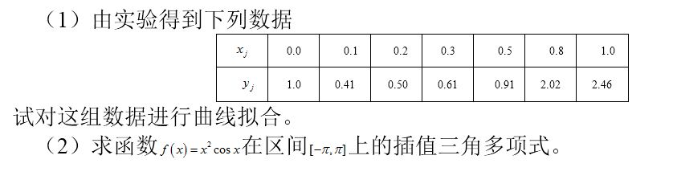

实验问题

# 三、实验要求

# 程序及代码

## 1. 3次与4次拟合多项式

```r
x<-c(0,0.9,1.9,3.0,3.9,5)
y<-c(0,10,30,50,80,110)
fitting<-function(x,y,k){#x，y是自变量和应变量k是需要拟合的多项式的次数
  #计算x所需要的数据
  xx<-matrix(data=NA,nrow=k+1,ncol = length(x))
  xx[1,]<-rep(1,length(x))
  for (i in 2:(k+1)) {
    xx[i,]<-x^(i-1)
  }
  #计算y所需要的数据
  yy<-matrix(data=NA,nrow=k+1,ncol = length(y))
  yy[1,]<-rep(1,length(y))
  for (i in 2:(k+1)) {
    yy[i,]<-y^(i-1)
  }
  #计算G所需的元素
  mat<-matrix(data=NA,nrow=k+1,ncol = k+1)
  for (i in 1:nrow(mat)) {
    for (j in 1:ncol(mat)) {
      # browser()
      mat[i,j]<-sum(xx[i,]*xx[j,])
    }
  }
  #计算d
  d<-vector(length = ncol(mat))
  for (i in 1:ncol(mat)) {
    d[i]<-sum(xx[i,]*y)
  }
  #求解
  result=solve(mat) %*% d
  return(result)
}
fitting(x=x,y=y,k=1)
```

```
##           [,1]
## [1,] -7.855048
## [2,] 22.253761
```

```r
x<-c(1,1,2,3,3,3,4,5)
y<-c(4,4,4.5,6,6,6,8,8.5)
fitting(x=x,y=y,k=1)
```

```
##          [,1]
## [1,] 2.564815
## [2,] 1.203704
```

```r
#两项测试通过
```

# 2.求解问题

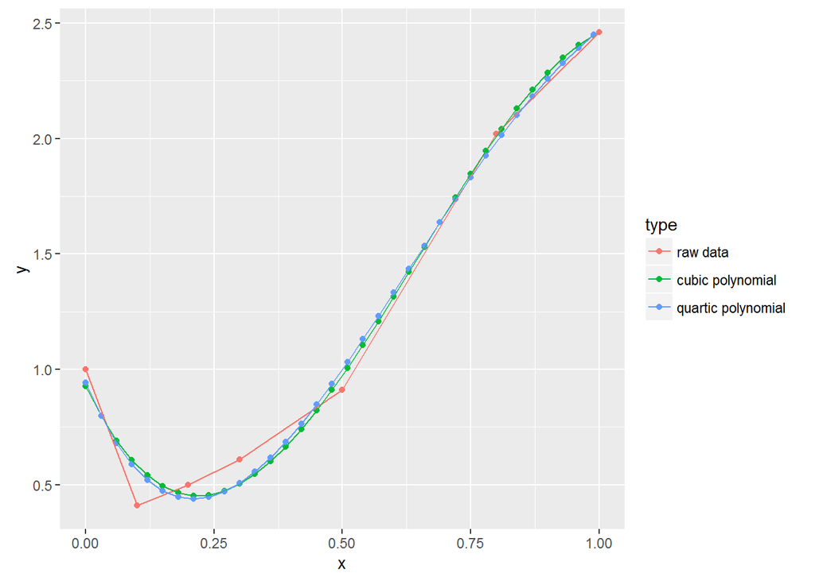

```r
x<-c(0,0.1,0.2,0.3,0.5,0.8,1)
y<-c(1,0.41,0.5,0.61,0.91,2.02,2.46)
cubic<-fitting(x=x,y=y,k=3)
quartic<-fitting(x=x,y=y,k=4)
#绘图
df<-data.frame(x=x,y=y,type=rep("raw data",length(x)))
x<-seq(from=0,to=1,by=0.03)
y<-cubic[1]+cubic[2]*x+cubic[3]*x^2+cubic[4]*x^3
df<-rbind(df,data.frame(x=x,y=y,type=rep("cubic polynomial",length(x))))
y<-quartic[1]+quartic[2]*x+quartic[3]*x^2+quartic[4]*x^3+quartic[5]*x^4
df<-rbind(df,data.frame(x=x,y=y,type=rep("quartic polynomial",length(x))))
library(ggplot2)
ggplot(data = df,aes(x=x,y=y,color=type))+geom_point()+geom_line()
```

```r
#利用R自带的统计函数进行验证
summary(lm(y~1+I(x)+I(x^2)+I(x^3)))
```

```
##
## Call:
## lm(formula = y ~ 1 + I(x) + I(x^2) + I(x^3))
##
## Residuals:
##       Min        1Q    Median        3Q       Max
## -0.018814 -0.012885 -0.001366  0.012917  0.032789
##
## Coefficients:
##              Estimate Std. Error t value Pr(>|t|)
## (Intercept)  0.909932   0.009639   94.40   <2e-16 ***
## I(x)        -4.533367   0.085590  -52.97   <2e-16 ***
## I(x^2)      12.673780   0.202641   62.54   <2e-16 ***
## I(x^3)      -6.621960   0.134450  -49.25   <2e-16 ***
## ---
## Signif. codes:  0 '***' 0.001 '**' 0.01 '*' 0.05 '.' 0.1 ' ' 1
##
## Residual standard error: 0.01563 on 30 degrees of freedom
## Multiple R-squared:  0.9995, Adjusted R-squared:  0.9995
## F-statistic: 2.103e+04 on 3 and 30 DF,  p-value: < 2.2e-16
```

```r
summary(lm(y~1+I(x)+I(x^2)+I(x^3)+I(x^4)))
```

```
##
## Call:
## lm(formula = y ~ 1 + I(x) + I(x^2) + I(x^3) + I(x^4))
##
## Residuals:
##        Min         1Q     Median         3Q        Max
## -2.683e-15 -3.795e-16 -6.146e-17  4.104e-16  2.283e-15
##
## Coefficients:
##               Estimate Std. Error    t value Pr(>|t|)
## (Intercept)  9.427e-01  6.775e-16  1.392e+15   <2e-16 ***
## I(x)        -5.299e+00  9.784e-15 -5.416e+14   <2e-16 ***
## I(x^2)       1.627e+01  4.108e-14  3.962e+14   <2e-16 ***
## I(x^3)      -1.233e+01  6.279e-14 -1.964e+14   <2e-16 ***
## I(x^4)       2.885e+00  3.145e-14  9.174e+13   <2e-16 ***
## ---
## Signif. codes:  0 '***' 0.001 '**' 0.01 '*' 0.05 '.' 0.1 ' ' 1
##
## Residual standard error: 9.33e-16 on 29 degrees of freedom
## Multiple R-squared:      1,  Adjusted R-squared:      1
## F-statistic: 4.426e+30 on 4 and 29 DF,  p-value: < 2.2e-16
```

# 三次多项式的系数与四次多项式的系数

三次多项式的系数为：0.926587, -4.6590662, 12.8147251, -6.6220615

四次多项式的系数为：0.942721, -5.2987276, 16.2747397, -12.3348255, 2.8852857

**从结果中可以看出：三次和四次的拟合结果相差不大。在开始的几个点中与原始数据差别比较大，之后拟合效果较好！**

# 3.讨论与不足

1. 在绘图的过程中暂时还无法调整到使原始数据点不成直线，而使其它点连成直线。 因为ggplot2本身就是一个很大的一个学习项目，自己有很多的语法，这里先暂时不做深究
2. 也可学习R本身自带的拟合函数，下面是学习的过程

# 学习R语言的拟合

**这里只学习lm这个函数，其它的函数见参考文件**

The main model-fitting commands covered on this page are:

- lm (linear models for fixed effects)
- lme (linear models for mixed effects)
- glm (generalized linear models)
- nls (nonlinear least squares)
- gam (generalized additive models)

Also covered is the use of

- visreg (to visualize model fits)
- lsmeans (to estimate predicted means)

## Fit a linear model to data

```r
z<-lm(y~x)
summary(z)#同最小二乘估计，结果相同！
```

```
##
## Call:
## lm(formula = y ~ x)
##
## Residuals:
##      Min       1Q   Median       3Q      Max
## -0.31134 -0.22394 -0.01884  0.17011  0.77532
##
## Coefficients:
##             Estimate Std. Error t value Pr(>|t|)
## (Intercept)  0.16740    0.08882   1.885   0.0686 .
## x            2.11470    0.15423  13.711 6.05e-15 ***
## ---
## Signif. codes:  0 '***' 0.001 '**' 0.01 '*' 0.05 '.' 0.1 ' ' 1
##
## Residual standard error: 0.2647 on 32 degrees of freedom
## Multiple R-squared:  0.8545, Adjusted R-squared:   0.85
## F-statistic:   188 on 1 and 32 DF,  p-value: 6.048e-15
```

Linear models for fixed effects are implemented in the lm method in R. You can pass a data frame to the lm command, using a formula to indicate the model you want to fit.

```r
z <- lm(response ~ explanatory, data = mydata)
z <- lm(response ~ explanatory, data = mydata, na.action = na.exclude)
```

The resulting object (which I’ve named z) is an *lm* object containing all the results. You use additional commands to pull out these results, including residuals and predicted values. The argument *na.action = na.exclude* is optional — it tells R to keep track of cases having missing values, in which case the residuals and predicted values will have NA’s inserted for those cases. Otherwise R just drops missing cases.

Here are some of the most useful functions to extract results from the lm object:

```r
summary(z)     # parameter estimates and overall model fit
# estimates of slope, intercept, SE's
plot(z)        # plots of residuals, normal quantiles, leverage
coef(z)        # model coefficients (means, slopes, intercepts) 系数的点估计
confint(z, level = 0.95)     # confidence intervals for parameters 系数的区间估计
#95% conf. intervals for slope and intercept
resid(z)       # residuals
predict(z)     # predicted values
predict(z, newdata = mynewdata) # see below
fitted(z)      # predicted values
anova(z1, z2)  # compare fits of 2 models, "full" vs "reduced"
anova(z)       # ANOVA table (** terms tested sequentially **)
#To test the null hypothesis of zero slope with the ANOVA table
```

The command *predict(z, newdata = mynewdata)* will used the model to predict values for new observations contained in the data frame *mynewdata*. The explanatory variables (the X variables) in mynewdata must have exactly the same names as in mydata.

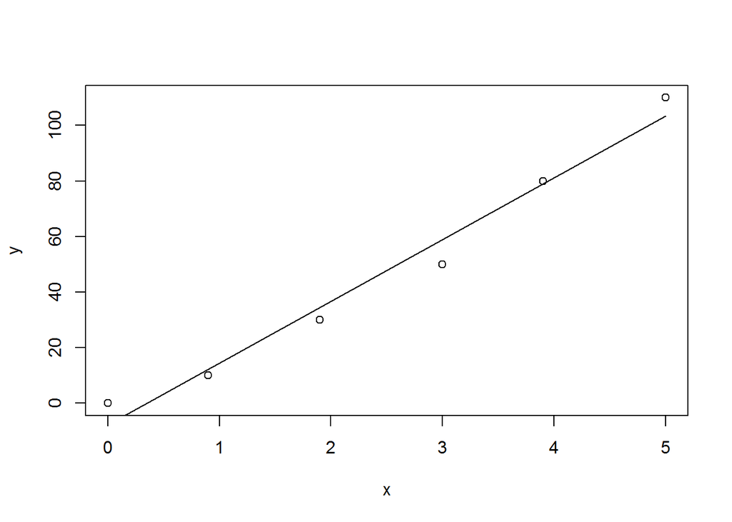

```r
#例子
mydata<-data.frame(
  x=c(0,0.9,1.9,3.0,3.9,5),
  y=c(0,10,30,50,80,110))
plot(y ~ x, data = mydata)
z <- lm(y ~ x, data = mydata)
xnew <- range(mydata$x)
yhat <- predict(z, newdata = data.frame(x = xnew))#新的预测值的写入方式
lines(yhat ~ xnew)#结果如下
```

```r
# In the case of simple linear regression you can add a line to a scatter plot of the data using the abline function.
# plot(response ~ explanatory, data = mydata)
```

Add confidence bands to your previous scatter plot:

```r
plot(y ~ x, data = mydata)
xnew <- seq(min(mydata$x), max(mydata$x), length.out = 100)
ynew <- data.frame(predict(z,
                   interval = "confidence", level = 0.95))#interval = c("none", "confidence", "prediction")
str(ynew)
```

```
## 'data.frame':    6 obs. of  3 variables:
##  $ fit: num  -7.86 12.17 34.43 58.91 78.93 ...
##  $ lwr: num  -22.2 1.1 25.8 50.3 68.2 ...
##  $ upr: num  6.47 23.24 43.05 67.53 89.69 ...
```

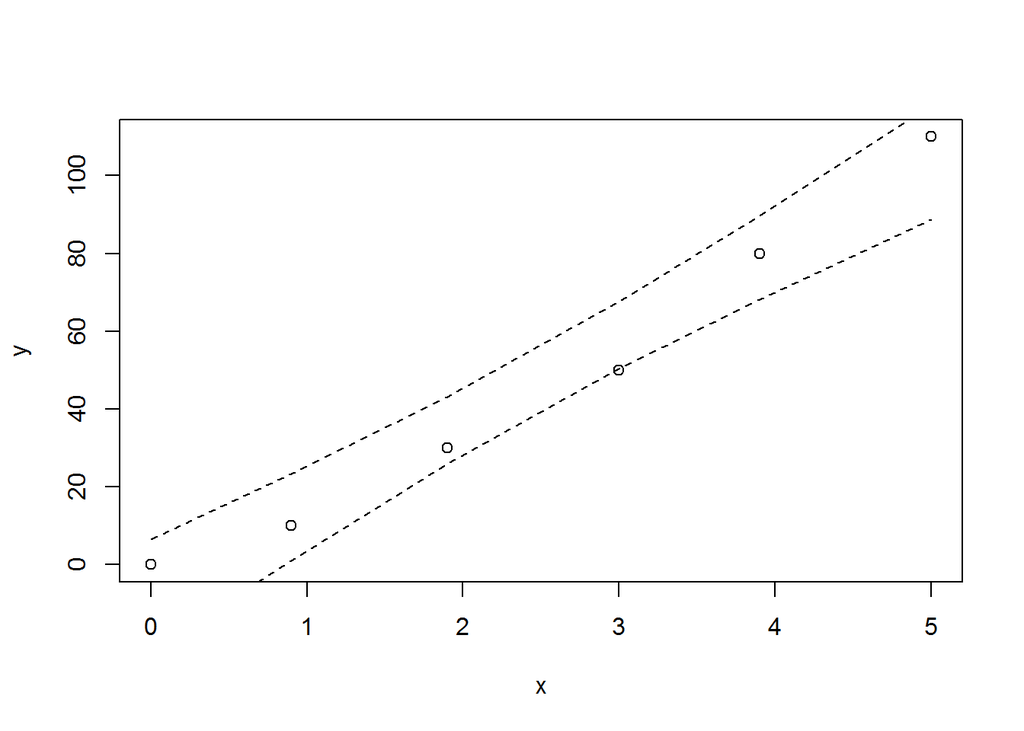

```r
lines(ynew$lwr ~ mydata$x, lty = 2)
lines(ynew$upr ~ mydata$x, lty = 2)
```

```r
plot(y ~ x, data = mydata)
xnew <- seq(min(mydata$x), max(mydata$x), length.out = 100)
ynew <- data.frame(predict(z, newdata = data.frame(x = xnew),
                   interval = "confidence", level = 0.95))#interval = c("none", "confidence", "prediction")
str(ynew)
```

```
## 'data.frame':    100 obs. of  3 variables:
##  $ fit: num  -7.86 -6.73 -5.61 -4.48 -3.36 ...
##  $ lwr: num  -22.2 -20.9 -19.5 -18.2 -16.9 ...
##  $ upr: num  6.47 7.4 8.32 9.25 10.18 ...
```

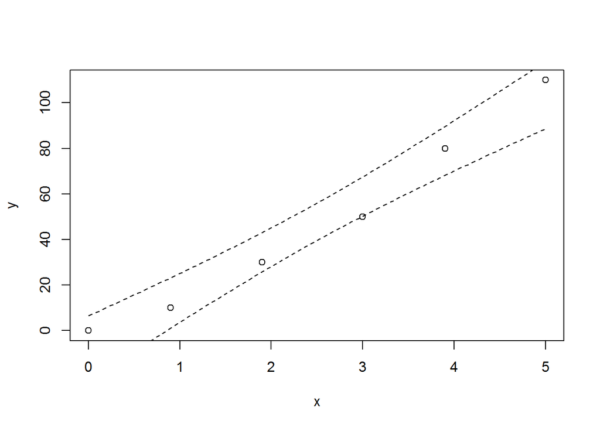

```r
lines(ynew$lwr ~ xnew, lty = 2)
lines(ynew$upr ~ xnew, lty = 2)
```

The intervals might not all squeeze onto the plot unless you adjust the limits of the y-axis using the *ylim =* option in the plot command.

### Basic types of linear models

The simplest linear model fits a constant, the mean, to a single variable. This is useful if you want to obtain an estimate of the mean with a standard error and confidence interval, or wanted to test the null hypothesis that the mean is zero.

就是常数回归

```r
#z <- lm(y ~ 1, data = mydata)
z <- lm(y ~ 1)
```

The most familiar linear model is the linear regression of y on x.

```r
# z <- lm(y ~ x, data = mydata)
z <- lm(y ~ x)#一次项回归
```

To fit a linear regression model without an intercept term, i.e., a regression through the origin, add “-1” to the model statement:

```r
# z <- lm(y ~ x - 1, data = mydata)
z <- lm(y ~ x - 1)
```

If A is a categorical variable (factor or character) rather than a numeric variable then the model conforms to a single factor ANOVA instead.

```r
x<-c(1,1,2,3,3,3,4,5)
y<-c(4,4,4.5,6,6,6,8,8.5)
#z <- lm(y ~ A, data = mydata)
A<-c("A","A","A","B","B","C","C","B")
z <- lm(y ~ A)
```

More complicated models include more variables and their interactions

```r
z1 <- lm(y ~ x1 + x2, data = mydata)          # no interaction between x1 and x2
z2 <- lm(y ~ x1 + x2 + x1:x2, data = mydata)  # interaction term present
z2 <- lm(y ~ x1 * x2, data = mydata)          # interaction term present
```

Analysis of *covariance models* include both numeric and categorical variables. The linear model in this case is a separate linear regression for each group of the categorical variable. Interaction terms between these two types of variables, if included in the model, fit different linear regression slopes; otherwise the same slope is forced upon every group.

```r
z <- lm(y ~ x + A + x:A, data = mydata)
```

# 参考资料

http://www.zoology.ubc.ca/~schluter/R/fit-model/

# 优秀参考资料

**关于多项式拟合等等**

http://blog.sina.com.cn/s/blog_6fbfcfb50102va2k.html